# ****ICA_SPRING 2025****

# Sir Farhan Ahmed Siddique

## Name(s) and Erp(s): Tehreem Javed(31109), Zamrah Irfan(), Sarim(26209)

## Class code: 98601

# ***Data name: LUNG CANCER TRENDS***

### Importing Libraries

##### This section imports all necessary Python libraries for data analysis, visualization, and modeling. Common libraries include pandas, numpy, matplotlib, seaborn

```python
import pandas as pd
import numpy as np
import matplotlib.pyplot as plt
import seaborn as sns
```

### Reading Data

##### Here, the dataset is read into a Pandas DataFrame using functions like pd.read_csv(). This step loads the data into memory so it can be analyzed and processed. We have chosen the Lung Cancer trends dataset for our analysis and visualizations which is given as follows;

```python
data=pd.read_csv("Lung_Cancer_Trends_With_Missing.csv")
data
```

|  | Patient_ID | Age | Gender | Smoking_Status | Years_Smoking | Cigarettes_Per_Day | Secondhand_Smoke_Exposure | Occupation_Exposure | Air_Pollution_Level | Family_History | ... | Diet_Quality | Region | Income_Level | Education_Level | Access_to_Healthcare | Screening_Frequency | Chronic_Lung_Disease | Lung_Cancer_Stage | Diagnosis_Year | Survival_Status |
| --- | --- | --- | --- | --- | --- | --- | --- | --- | --- | --- | --- | --- | --- | --- | --- | --- | --- | --- | --- | --- | --- |
| 0 | P100000 | NaN | Female | Never | 6 | 37 | Low | Diesel Fumes | Low | Yes | ... | Poor | West | Middle | Tertiary | Good | Regularly | No | Stage II | 2008 | Alive |
| 1 | P100001 | 39.0 | Male | Never | 30 | 39 | Low | Silica | Low | Yes | ... | Average | North | Middle | Primary | Poor | Occasionally | Yes | NaN | 2002 | Alive |
| 2 | P100002 | 85.0 | Male | NaN | 47 | 14 | High | Asbestos | Low | Yes | ... | Good | South | High | Tertiary | Average | Regularly | No | Stage II | 2007 | Deceased |
| 3 | P100003 | 45.0 | Female | Current | 45 | 32 | Medium | Silica | High | No | ... | Good | West | Low | Secondary | Average | Never | Yes | NaN | 2011 | Alive |
| 4 | P100004 | 48.0 | Female | Never | 46 | 26 | Medium | Silica | Low | No | ... | Good | North | Low | Tertiary | Average | Regularly | No | NaN | 2016 | Alive |
| ... | ... | ... | ... | ... | ... | ... | ... | ... | ... | ... | ... | ... | ... | ... | ... | ... | ... | ... | ... | ... | ... |
| 2995 | P102995 | 39.0 | Male | Current | 15 | 27 | Low | Silica | High | No | ... | Average | East | Middle | NaN | Poor | Regularly | No | NaN | 2022 | Alive |
| 2996 | P102996 | 61.0 | Male | Former | 5 | 13 | High | Silica | Moderate | Yes | ... | Good | East | High | Primary | Poor | Occasionally | No | Stage III | 2019 | Deceased |
| 2997 | P102997 | 25.0 | Male | Never | 6 | 33 | High | Silica | High | Yes | ... | Poor | East | Low | Secondary | Poor | Never | No | Stage IV | 2009 | Alive |
| 2998 | P102998 | 48.0 | Male | Current | 49 | 10 | Medium | NaN | Low | Yes | ... | Average | West | Low | Secondary | Average | Occasionally | No | NaN | 2008 | Alive |
| 2999 | P102999 | 51.0 | Male | Never | 13 | 12 | High | Silica | Moderate | Yes | ... | Average | South | High | Tertiary | Average | Never | No | Stage III | 2015 | Alive |

3000 rows × 24 columns

# Chapter 1: System Study and Domain Analysis

### 'Business Process Description:

##### This project is based on a healthcare dataset titled “Lung Cancer Trends,” which captures longitudinal trends in lung cancer cases, mortality, and related statistics across different populations, possibly segmented by geography, gender, age group, smoking status, or year. The dataset appears to have missing values, suggesting real-world incompleteness typical of public health data, making it relevant for practical data analysis and imputation strategies.

##### The underlying business (or health system) process involves the public health surveillance and epidemiological monitoring of one of the deadliest forms of cancer globally: lung cancer. The data could be collected by government agencies, hospitals, cancer registries, or global health organizations.

#### The broader process includes:

##### Data Collection from Medical and National Registries:

##### Hospitals, cancer centers, and public health institutes report the incidence, treatment, and outcomes of lung cancer cases. These include number of diagnoses, deaths, and possibly survival rates across demographics.

#### Disease Monitoring and Analysis:

##### Epidemiologists and researchers study the data to identify high-risk groups, detect changes over time, and uncover patterns such as regional hotspots or rising cases among certain age groups or genders.

#### Public Health Decision-Making:

##### Health policymakers rely on these trends to allocate resources, run awareness campaigns (e.g., anti-smoking drives), fund research, or improve early detection programs.

#### Medical Research and Clinical Focus:

##### Trends in data help medical scientists target the disease’s root causes, such as environmental pollutants or genetic predisposition, and track the effectiveness of interventions like smoking cessation programs.

### Types of Analytics Possible:

#### Descriptive Analytics:

##### Summarizing total number of cases and deaths over the years.

##### Visualizing trends in lung cancer by gender, age, and location.

##### Identifying years or regions with highest incidence or mortality.

##### Describing data completeness and highlighting missing values.

#### Diagnostic Analytics:

##### Understanding why certain regions or demographics have higher rates.

##### Analyzing the correlation between smoking data (if included) and lung cancer trends.

##### Comparing survival rates based on treatment or diagnosis stage (if available).

#### Predictive Analytics:

##### Predicting future lung cancer cases or death counts using historical data.

##### Forecasting regional or demographic risk using regression models or time-series analysis.

##### Classifying high-risk populations using machine learning algorithms.

#### Prescriptive Analytics:

##### Recommending targeted screening in regions with rising trends.

##### Optimizing public health budgets based on predicted high-need areas.

##### Identifying the most effective preventive measures based on success history.

#### Business / Research Usefulness:

##### Public Health Departments:

##### Can use the insights to plan interventions, smoking cessation programs, and awareness campaigns.

##### Healthcare Providers & Hospitals:

##### May allocate more resources, diagnostic equipment, and specialists to regions showing increasing cases.

##### Cancer Researchers:

##### Can detect early patterns or anomalies for deeper biological investigation, and evaluate the effectiveness of existing treatments or detection methods.

##### Policy Makers & NGOs:

##### May use these findings to legislate tobacco control, pollution regulations, or healthcare funding decisions.

##### Academic Institutions:

##### Provides a solid base for capstone projects, statistical modeling, epidemiology research, and curriculum development.

##### General Public & Media:

##### Can benefit from simplified summaries and visualizations for education and awareness.

### 1.Data Shape

##### we use .shape to check the number of rows and columns in the dataset. This returns a tuple: (number of rows, number of columns), allowing us to quickly assess the size of the dataset.This step is crucial as it sets the stage for all further analysis by ensuring we’re working with the correct data and understanding its scale.

```python
data.shape
```

```
(3000, 24)
```

The shape function gives us the total number of rows and columns in our dataset

### 2.Dataset Composition

##### We use data.dtypes to check the data type of each column. This helps us understand whether the columns are numeric, categorical, or contain text, and ensures they are in the correct format for analysis and modeling.

```python
data.dtypes
```

```
Patient_ID                    object
Age                           object
Gender                        object
Smoking_Status                object
Years_Smoking                  int64
Cigarettes_Per_Day             int64
Secondhand_Smoke_Exposure     object
Occupation_Exposure           object
Air_Pollution_Level           object
Family_History                object
Genetic_Markers_Positive      object
BMI                          float64
Physical_Activity_Level       object
Alcohol_Consumption           object
Diet_Quality                  object
Region                        object
Income_Level                  object
Education_Level               object
Access_to_Healthcare          object
Screening_Frequency           object
Chronic_Lung_Disease          object
Lung_Cancer_Stage             object
Diagnosis_Year                 int64
Survival_Status               object
dtype: object
```

### 3.Dataset Information

###### .info() provides a summary including data types and non-null counts, which helps identify missing values and data formats.

```python
data.info()
```

[output not shown]

[output cut: 16 more lines]

#### This gives us a quick snapshot of what the data looks like, including:

##### Column names

##### Data formats

##### Example entries

### 4.Dataset head

##### We use data.head() to display the first few rows of the dataset and get a quick overview of its structure and contents.

```python
data.head(10)
```

|  | Patient_ID | Age | Gender | Smoking_Status | Years_Smoking | Cigarettes_Per_Day | Secondhand_Smoke_Exposure | Occupation_Exposure | Air_Pollution_Level | Family_History | ... | Diet_Quality | Region | Income_Level | Education_Level | Access_to_Healthcare | Screening_Frequency | Chronic_Lung_Disease | Lung_Cancer_Stage | Diagnosis_Year | Survival_Status |
| --- | --- | --- | --- | --- | --- | --- | --- | --- | --- | --- | --- | --- | --- | --- | --- | --- | --- | --- | --- | --- | --- |
| 0 | P100000 | NaN | Female | Never | 6 | 37 | Low | Diesel Fumes | Low | Yes | ... | Poor | West | Middle | Tertiary | Good | Regularly | No | Stage II | 2008 | Alive |
| 1 | P100001 | 39.0 | Male | Never | 30 | 39 | Low | Silica | Low | Yes | ... | Average | North | Middle | Primary | Poor | Occasionally | Yes | NaN | 2002 | Alive |
| 2 | P100002 | 85.0 | Male | NaN | 47 | 14 | High | Asbestos | Low | Yes | ... | Good | South | High | Tertiary | Average | Regularly | No | Stage II | 2007 | Deceased |
| 3 | P100003 | 45.0 | Female | Current | 45 | 32 | Medium | Silica | High | No | ... | Good | West | Low | Secondary | Average | Never | Yes | NaN | 2011 | Alive |
| 4 | P100004 | 48.0 | Female | Never | 46 | 26 | Medium | Silica | Low | No | ... | Good | North | Low | Tertiary | Average | Regularly | No | NaN | 2016 | Alive |
| 5 | P100005 | NaN | Male | Current | 13 | 28 | Low | Silica | High | No | ... | Poor | East | Middle | Tertiary | Average | Regularly | No | NaN | 2013 | Alive |
| 6 | P100006 | 46.0 | Female | Current | 27 | 36 | Low | Asbestos | High | Yes | ... | Good | West | Middle | Primary | Good | Occasionally | Yes | Stage II | 2015 | Deceased |
| 7 | P100007 | 77.0 | Female | Never | 42 | 4 | Low | NaN | Low | Yes | ... | Poor | East | High | Primary | Good | Regularly | No | Stage III | 2018 | Alive |
| 8 | P100008 | 26.0 | Female | Never | 15 | 28 | Medium | Silica | Low | No | ... | Poor | South | Middle | Tertiary | Poor | Never | No | NaN | 2003 | Alive |
| 9 | P100009 | 54.0 | Female | Never | 18 | 31 | Medium | Diesel Fumes | Low | Yes | ... | Good | West | Middle | Secondary | Average | Never | No | NaN | 2002 | Alive |

10 rows × 24 columns

### 4.Dataset tail

##### We use data.tail() to view the last few rows of the dataset, which helps verify the data's consistency and structure toward the end.

```python
data.tail(10)
```

|  | Patient_ID | Age | Gender | Smoking_Status | Years_Smoking | Cigarettes_Per_Day | Secondhand_Smoke_Exposure | Occupation_Exposure | Air_Pollution_Level | Family_History | ... | Diet_Quality | Region | Income_Level | Education_Level | Access_to_Healthcare | Screening_Frequency | Chronic_Lung_Disease | Lung_Cancer_Stage | Diagnosis_Year | Survival_Status |
| --- | --- | --- | --- | --- | --- | --- | --- | --- | --- | --- | --- | --- | --- | --- | --- | --- | --- | --- | --- | --- | --- |
| 2990 | P102990 | 32.0 | Female | Never | 4 | 33 | Low | Diesel Fumes | Moderate | No | ... | Average | East | High | Tertiary | Good | Occasionally | No | NaN | 2013 | Alive |
| 2991 | P102991 | 65.0 | Male | Former | 17 | 33 | High | Diesel Fumes | Low | No | ... | Poor | East | Middle | Secondary | Average | Never | No | NaN | 2017 | Alive |
| 2992 | P102992 | 43.0 | Female | Never | 2 | 35 | High | Asbestos | Moderate | No | ... | Good | East | High | Secondary | Good | Never | No | NaN | 2009 | Alive |
| 2993 | P102993 | 70.0 | Female | Current | 26 | 34 | High | Diesel Fumes | Low | Yes | ... | Poor | East | Middle | Secondary | Good | Regularly | No | NaN | 2015 | Alive |
| 2994 | P102994 | 52.0 | Male | Former | 16 | 16 | Low | Asbestos | Low | Yes | ... | Good | North | High | Tertiary | Poor | Regularly | No | NaN | 2021 | Alive |
| 2995 | P102995 | 39.0 | Male | Current | 15 | 27 | Low | Silica | High | No | ... | Average | East | Middle | NaN | Poor | Regularly | No | NaN | 2022 | Alive |
| 2996 | P102996 | 61.0 | Male | Former | 5 | 13 | High | Silica | Moderate | Yes | ... | Good | East | High | Primary | Poor | Occasionally | No | Stage III | 2019 | Deceased |
| 2997 | P102997 | 25.0 | Male | Never | 6 | 33 | High | Silica | High | Yes | ... | Poor | East | Low | Secondary | Poor | Never | No | Stage IV | 2009 | Alive |
| 2998 | P102998 | 48.0 | Male | Current | 49 | 10 | Medium | NaN | Low | Yes | ... | Average | West | Low | Secondary | Average | Occasionally | No | NaN | 2008 | Alive |
| 2999 | P102999 | 51.0 | Male | Never | 13 | 12 | High | Silica | Moderate | Yes | ... | Average | South | High | Tertiary | Average | Never | No | Stage III | 2015 | Alive |

10 rows × 24 columns

# Chapter 2: Data Cleaning

## Data Type Analysis and Conversion

#### Data cleaning is a crucial step in the data analysis process, ensuring that the dataset is accurate, consistent, and ready for meaningful analysis. In this stage, we identify and handle common issues such as missing values, incorrect data types, duplicate records, and inconsistent formatting.

### Key tasks typically performed include:

### Handling Missing Values:

##### Detecting and dealing with NaN values by either removing, filling (imputing), or flagging them depending on the context and importance of the column.

### Fixing Data Types:

##### Converting columns to the correct data types (e.g., from object to integer or float) to enable proper calculations and comparisons.

### Removing Duplicates:

##### Checking for and removing any duplicate rows that may distort analysis results.

### Standardizing Categorical Data:

##### Ensuring consistency in category names (e.g., “Male” vs. “male” vs. “M”) using methods like .str.lower() and .replace().

### Outlier Detection (optional):

##### Identifying and managing outliers if they are likely to skew analysis or model performance.

#### Cleaning the data improves the reliability and quality of all future analysis and modeling steps. It is often said that “80% of data science is data cleaning”, highlighting how foundational this chapter is to the success of your project.

## Handling Missing Values

### 3.Count missing/null values

##### This code checks each column for missing (null) values to identify what needs cleaning.

```python
print("\nMissing values per column:\n")
print(data.isnull().sum())
```

```
Missing values per column:

Patient_ID                      0
Age                           251
Gender                          0
Smoking_Status                200
Years_Smoking                   0
Cigarettes_Per_Day              0
Secondhand_Smoke_Exposure       0
Occupation_Exposure           851
Air_Pollution_Level             0
Family_History                  0
Genetic_Markers_Positive        0
BMI                           210
Physical_Activity_Level         0
Alcohol_Consumption           975
Diet_Quality                    0
Region                          0
Income_Level                    0
Education_Level               150
Access_to_Healthcare            0
Screening_Frequency             0
Chronic_Lung_Disease            0
Lung_Cancer_Stage            2402
Diagnosis_Year                  0
Survival_Status                 0
dtype: int64
```

.isnull().sum() here provides us the total count of the missing values in each column of our dataset

```python
# Replace string-based errors in 'Age' with NaN
data['Age'] = pd.to_numeric(data['Age'], errors='coerce')
```

This line of code converts the 'Age' column in the data DataFrame to numeric values, replacing any non-numeric entries with NaN. This is useful for ensuring that the 'Age' column contains only numeric data, which can be important for analysis and calculations.

```python
# Clean 'Smoking_Status' where numeric values were mistakenly inserted
data['Smoking_Status'] = data['Smoking_Status'].replace({0: np.nan, 1: np.nan})
```

```python
# Replace empty strings with NaN in specific columns
data['Occupation_Exposure'].replace('', np.nan)
data['Education_Level'].replace('', np.nan)
data['Alcohol_Consumption'].replace('', np.nan)
data['Lung_Cancer_Stage'].replace('', np.nan)
```

```
0        Stage II
1             NaN
2        Stage II
3             NaN
4             NaN
          ...
2995          NaN
2996    Stage III
2997     Stage IV
2998          NaN
2999    Stage III
Name: Lung_Cancer_Stage, Length: 3000, dtype: object
```

Each line of code is replacing empty strings in specific columns with np.nan, which is useful for data cleaning and ensuring that missing or invalid data is properly marked.

```python
# Final check of missing values after all replacements
print("\nUpdated missing values after cleaning:\n")
print(data.isnull().sum())
```

```
Updated missing values after cleaning:

Patient_ID                      0
Age                           292
Gender                          0
Smoking_Status                200
Years_Smoking                   0
Cigarettes_Per_Day              0
Secondhand_Smoke_Exposure       0
Occupation_Exposure           851
Air_Pollution_Level             0
Family_History                  0
Genetic_Markers_Positive        0
BMI                           210
Physical_Activity_Level         0
Alcohol_Consumption           975
Diet_Quality                    0
Region                          0
Income_Level                    0
Education_Level               150
Access_to_Healthcare            0
Screening_Frequency             0
Chronic_Lung_Disease            0
Lung_Cancer_Stage            2402
Diagnosis_Year                  0
Survival_Status                 0
dtype: int64
```

Finally checking once more that missing values exist or not in the dataframe for a quick verification

### 4. Impute missing values

##### Impute Missing Values refers to the process of replacing missing or incomplete data in a dataset with estimated values. This technique helps to maintain the integrity of the dataset and allows for more accurate analysis and modeling. Common methods include using the mean, median, mode, or more advanced approaches like regression or machine learning algorithms to predict the missing entries.

```python
# Fill missing numeric values with mean
data['Age'].fillna(data['Age'].mean())
data['BMI'].fillna(data['BMI'].mean())
data['Alcohol_Consumption'].fillna(data['Alcohol_Consumption'].mode()[0])
data['Lung_Cancer_Stage'].fillna(data['Lung_Cancer_Stage'].mode()[0])
```

```
0        Stage II
1         Stage I
2        Stage II
3         Stage I
4         Stage I
          ...
2995      Stage I
2996    Stage III
2997     Stage IV
2998      Stage I
2999    Stage III
Name: Lung_Cancer_Stage, Length: 3000, dtype: object
```

Here we are basically filling all the missing values in our dataframe with the respective averages i.e mean, median, mode column

```python
#converting data['Age'] (float) to integer
data['Age'] = data['Age'].round().astype(int)
```

Here we are converting the age column of our dataset from float datatype to integer datatype

```python
# Fill missing categorical values with mode
for col in ['Smoking_Status', 'Occupation_Exposure', 'Education_Level']:
    data[col].fillna(data[col].mode()[0])
```

Here we are filling in the missing values of a column with its mode computed

### 5. Fix inconsistent data in categorical columns

##### Fix Inconsistent Data in Categorical Columns involves identifying and correcting variations or errors in category labels within a dataset. This includes standardizing different spellings, capitalizations, or formats of the same category (e.g., “Male,” “male,” and “M” all representing the same group). Cleaning these inconsistencies ensures accurate grouping, analysis, and modeling of categorical data.

```python
# Clean 'Gender' where 1=Male, 2=Female were inconsistently mixed
data['Gender'] = data['Gender'].replace({1: 'Male', 2: 'Female'})
data['Gender'] = data['Gender'].str.capitalize()
```

```python
# Fix case inconsistencies in 'Smoking_Status'
data['Smoking_Status'] = data['Smoking_Status'].str.capitalize()
```

Another way to capitalize or make the string data in the smoking status column uppercase

### 6. Validate cleanup

##### Validate Cleanup is the process of verifying that all data cleaning steps, such as handling missing values and fixing inconsistencies, have been correctly applied. This involves checking the dataset to ensure no errors remain, the data is consistent, and it is ready for accurate analysis or modeling. Validation helps maintain data quality and reliability throughout the workflow.

```python
# Confirm data types and no remaining missing values
data.info()
print("\nMissing values (final check):\n", data.isnull().sum())
```

[output not shown]

This gives us an overview of our entire dataset indicating the datatypes of our columns as well as giving us a hint whether there are missing values present in our dataset or not

```python
data
```

|  | Patient_ID | Age | Gender | Smoking_Status | Years_Smoking | Cigarettes_Per_Day | Secondhand_Smoke_Exposure | Occupation_Exposure | Air_Pollution_Level | Family_History | ... | Diet_Quality | Region | Income_Level | Education_Level | Access_to_Healthcare | Screening_Frequency | Chronic_Lung_Disease | Lung_Cancer_Stage | Diagnosis_Year | Survival_Status |
| --- | --- | --- | --- | --- | --- | --- | --- | --- | --- | --- | --- | --- | --- | --- | --- | --- | --- | --- | --- | --- | --- |
| 0 | P100000 | 57 | Female | Never | 6 | 37 | Low | Diesel Fumes | Low | Yes | ... | Poor | West | Middle | Tertiary | Good | Regularly | No | Stage II | 2008 | Alive |
| 1 | P100001 | 39 | Male | Never | 30 | 39 | Low | Silica | Low | Yes | ... | Average | North | Middle | Primary | Poor | Occasionally | Yes | Stage I | 2002 | Alive |
| 2 | P100002 | 85 | Male | Current | 47 | 14 | High | Asbestos | Low | Yes | ... | Good | South | High | Tertiary | Average | Regularly | No | Stage II | 2007 | Deceased |
| 3 | P100003 | 45 | Female | Current | 45 | 32 | Medium | Silica | High | No | ... | Good | West | Low | Secondary | Average | Never | Yes | Stage I | 2011 | Alive |
| 4 | P100004 | 48 | Female | Never | 46 | 26 | Medium | Silica | Low | No | ... | Good | North | Low | Tertiary | Average | Regularly | No | Stage I | 2016 | Alive |
| ... | ... | ... | ... | ... | ... | ... | ... | ... | ... | ... | ... | ... | ... | ... | ... | ... | ... | ... | ... | ... | ... |
| 2995 | P102995 | 39 | Male | Current | 15 | 27 | Low | Silica | High | No | ... | Average | East | Middle | Secondary | Poor | Regularly | No | Stage I | 2022 | Alive |
| 2996 | P102996 | 61 | Male | Former | 5 | 13 | High | Silica | Moderate | Yes | ... | Good | East | High | Primary | Poor | Occasionally | No | Stage III | 2019 | Deceased |
| 2997 | P102997 | 25 | Male | Never | 6 | 33 | High | Silica | High | Yes | ... | Poor | East | Low | Secondary | Poor | Never | No | Stage IV | 2009 | Alive |
| 2998 | P102998 | 48 | Male | Current | 49 | 10 | Medium | Diesel Fumes | Low | Yes | ... | Average | West | Low | Secondary | Average | Occasionally | No | Stage I | 2008 | Alive |
| 2999 | P102999 | 51 | Male | Never | 13 | 12 | High | Silica | Moderate | Yes | ... | Average | South | High | Tertiary | Average | Never | No | Stage III | 2015 | Alive |

3000 rows × 24 columns

```python
data.shape
```

```
(3000, 24)
```

```python
data.describe()
```

|  | Age | Years_Smoking | Cigarettes_Per_Day | BMI | Diagnosis_Year |
| --- | --- | --- | --- | --- | --- |
| count | 3000.000000 | 3000.000000 | 3000.000000 | 3000.000000 | 3000.000000 |
| mean | 56.789000 | 24.226000 | 19.624000 | 24.918638 | 2012.129667 |
| std | 17.730744 | 14.292924 | 11.430289 | 4.766658 | 7.248105 |
| min | 25.000000 | 0.000000 | 0.000000 | 2.600000 | 2000.000000 |
| 25% | 42.750000 | 12.000000 | 10.000000 | 21.875000 | 2006.000000 |
| 50% | 57.000000 | 24.000000 | 19.000000 | 24.918638 | 2012.000000 |
| 75% | 71.000000 | 36.000000 | 29.000000 | 28.000000 | 2018.000000 |
| max | 89.000000 | 49.000000 | 39.000000 | 45.700000 | 2024.000000 |

### Exporting clean data to csv

```python
data = pd.DataFrame(data)
#Write to CSV
data.to_csv('Output.csv', index = True)
```

This code creates a pandas DataFrame from the data variable and then writes this DataFrame to a CSV file named 'Output.csv', including the index in the file.

# Chapter 3: Exploratory Data Analysis

# ***1.Univariate Analysis***

# 1. Numerical Variable Analysis

# ***BOX PLOT***

### Plot the boxplots and distribution plots of all the numeric variables and discuss their distribution as normal or not. If normal, then whether it is right skewed or left skewed.

### 1.Box plot of AGES

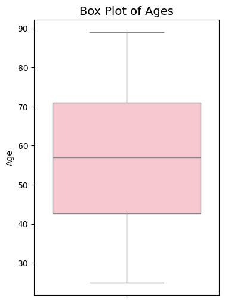

```python
plt.figure(figsize=(4,6))
sns.boxplot(data['Age'], color='pink',patch_artist=True)
plt.title("Box Plot of Ages", size=14)
plt.show()
```

This code creates a figure with a size of 4x6 inches, generates a pink box plot of the 'Age' column from the data DataFrame, sets the title of the plot to "Box Plot of Ages" with a font size of 14, and then displays the plot. From this plot, we can infer the following:

Skewness:

### 2.Box plot of YEARS SMOKING

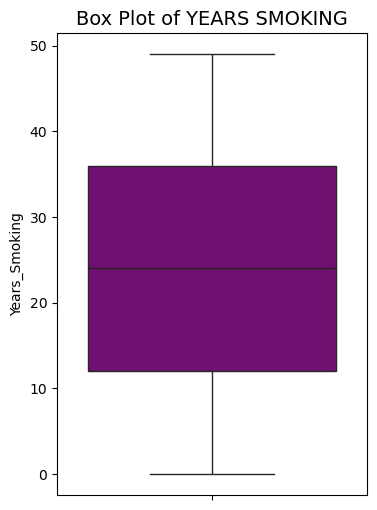

```python
plt.figure(figsize=(4,6))
sns.boxplot(data['Years_Smoking'], color='purple',patch_artist=True)
plt.title("Box Plot of YEARS SMOKING", size=14)
plt.show()
```

Same as for Box plot for Ages except for the fact that from this plot, we can infer the following:

Skewness:

### 3.Box plot of CIGARETTES PER DAY

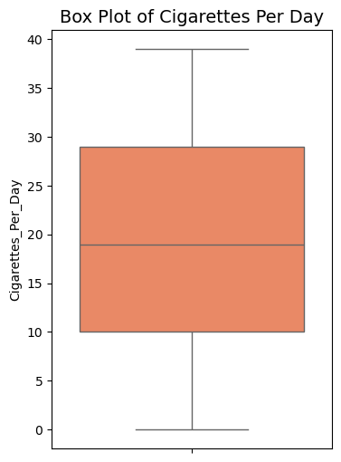

```python
plt.figure(figsize=(4,6))
sns.boxplot(data['Cigarettes_Per_Day'], color='coral',patch_artist=True)
plt.title("Box Plot of Cigarettes Per Day", size=14)
plt.show()
```

### 4.Box plot of BMI

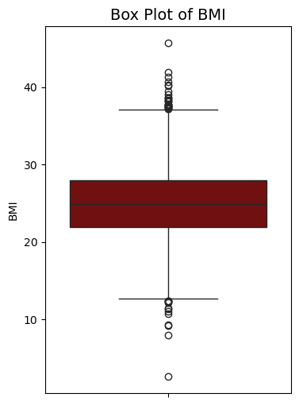

```python
plt.figure(figsize=(4,6))
sns.boxplot(data['BMI'], color='maroon',patch_artist=True)
plt.title("Box Plot of BMI", size=14)
plt.show()
```

### 5.Box plot of DIAGNOSIS YEAR

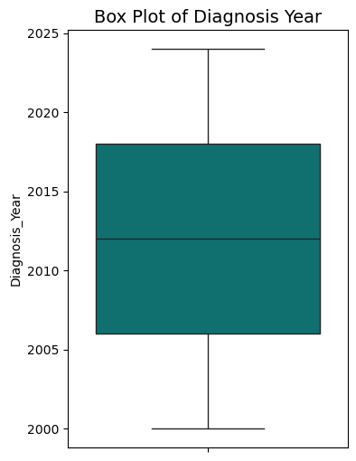

```python
plt.figure(figsize=(4,6))
sns.boxplot(data['Diagnosis_Year'], color='teal',patch_artist=True)
plt.title("Box Plot of Diagnosis Year", size=14)
plt.show()
```

# ***HISTOGRAM WITH KDE***

### 1.Histogram of AGES

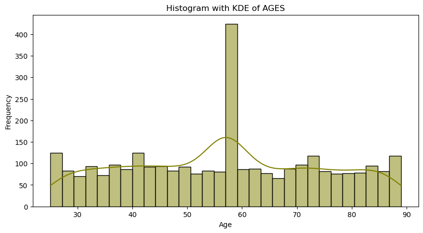

```python
plt.figure(figsize=(10,5))
sns.histplot(data['Age'], kde=True, bins=30, color='olive', edgecolor='black')
plt.title("Histogram with KDE of AGES")
plt.xlabel("Age")
plt.ylabel("Frequency")
plt.show()
```

Statistical Inferences:

Interpretation:

### 2.Histogram of YEARS SMOKING

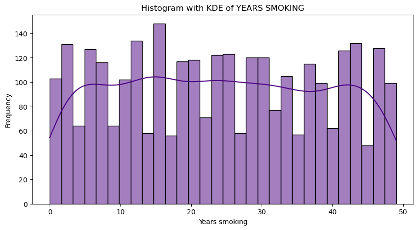

```python
plt.figure(figsize=(10,5))
sns.histplot(data['Years_Smoking'], kde=True, bins=30, color='indigo', edgecolor='black')
plt.title('Histogram with KDE of YEARS SMOKING')
plt.xlabel('Years smoking')
plt.ylabel('Frequency')
plt.show()
```

Statistical Inferences:

Mode Years Smoking: 3

Skewness of Years Smoking: -0.17

### 3.Histogram of CIGARETTES PER DAY

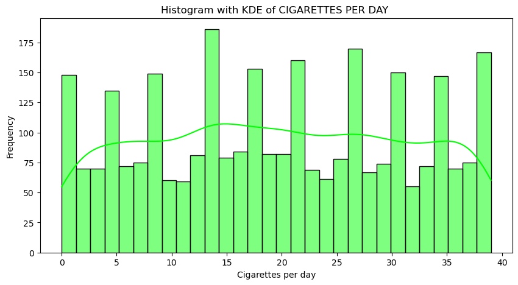

```python
plt.figure(figsize=(10,5))
sns.histplot(data['Cigarettes_Per_Day'], kde=True, bins=30, color='lime', edgecolor='black')
plt.title('Histogram with KDE of CIGARETTES PER DAY ')
plt.xlabel('Cigarettes per day')
plt.ylabel('Frequency')
plt.show()
```

Statistical Inferences:

### 4.Histogram of BMI

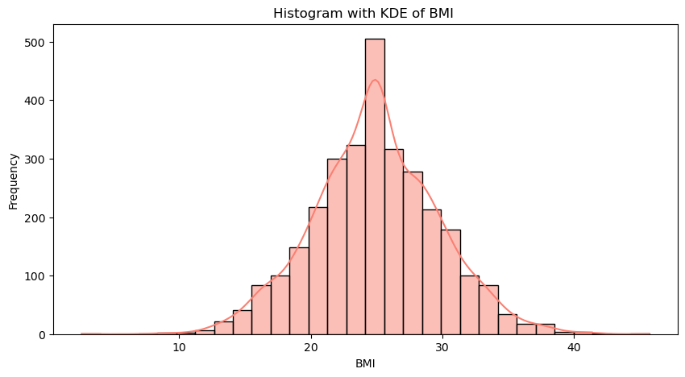

```python
plt.figure(figsize=(10,5))
sns.histplot(data['BMI'], kde=True, bins=30, color='salmon', edgecolor='black')
plt.title('Histogram with KDE of BMI ')
plt.xlabel('BMI')
plt.ylabel('Frequency')
plt.show()
```

Statistical Inferences:

### 5.Histogram of DIAGNOSIS YEAR

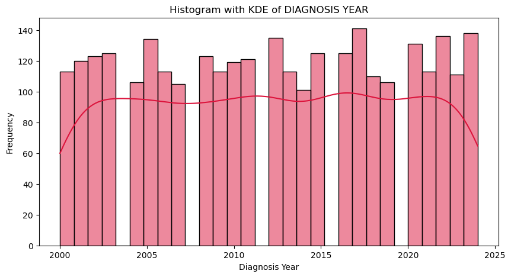

```python
plt.figure(figsize=(10,5))
sns.histplot(data['Diagnosis_Year'], kde=True, bins=30, color='crimson', edgecolor='black')
plt.title('Histogram with KDE of DIAGNOSIS YEAR')
plt.xlabel('Diagnosis Year')
plt.ylabel('Frequency')
plt.show()
```

Statistical Inferences:

# 2. Categorical Variable Analysis

# ***BAR PLOT***

### 1. Bar chart of GENDER

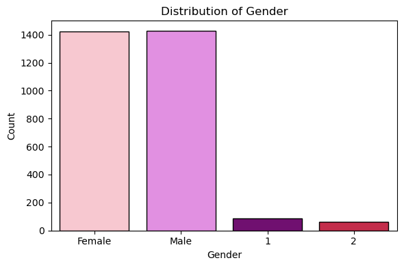

```python
plt.figure(figsize=(6, 4))
colors=['pink','violet', 'purple','crimson']
sns.countplot(data, x='Gender',hue='Gender', palette=colors, edgecolor='black')
plt.title('Distribution of Gender')
plt.xlabel('Gender')
plt.ylabel('Count')
plt.tight_layout()
plt.show()
```

Statistical Inferences:

### 2. Bar chart of SMOKING STATUS

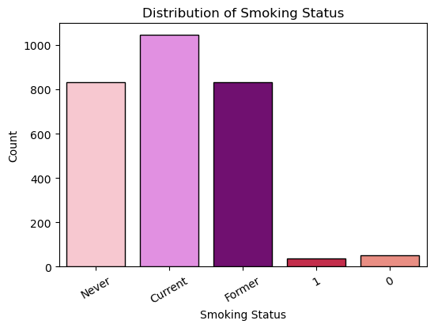

```python
plt.figure(figsize=(6, 4))
colors=['pink','violet', 'purple','crimson','salmon']
sns.countplot(data, x='Smoking_Status', hue='Smoking_Status', palette=colors, edgecolor='black', legend=False)
plt.title('Distribution of Smoking Status')
plt.xlabel('Smoking Status')
plt.ylabel('Count')
plt.xticks(rotation=30)
plt.show()
```

Statistical Inferences:

### 3. Bar chart of SECOND HAND SMOKING EXPOSURE

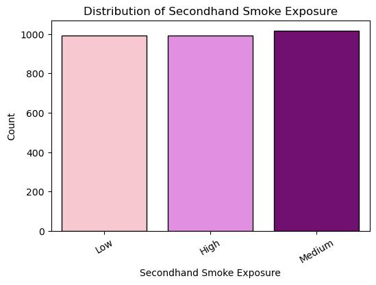

```python
plt.figure(figsize=(6, 4))
colors2=['pink','violet', 'purple']
sns.countplot(data, x='Secondhand_Smoke_Exposure', hue='Secondhand_Smoke_Exposure', palette=colors2, edgecolor='black', legend=False)
plt.title('Distribution of Secondhand Smoke Exposure')
plt.xlabel('Secondhand Smoke Exposure')
plt.ylabel('Count')
plt.xticks(rotation=30)
plt.show()
```

### 5.Bar chart of AIR POLLUTION LEVEL

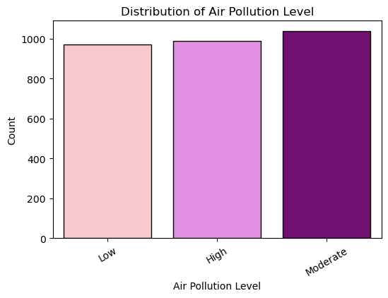

```python
plt.figure(figsize=(6, 4))
colors2=['pink','violet', 'purple']
sns.countplot(data, x='Air_Pollution_Level', hue='Air_Pollution_Level', palette=colors2, edgecolor='black', legend=False)
plt.title('Distribution of Air Pollution Level')
plt.xlabel('Air Pollution Level')
plt.ylabel('Count')
plt.xticks(rotation=30)
plt.show()
```

Statistical Inferences:

### 6.Bar chart of FAMILY HISTORY

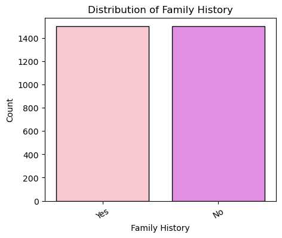

```python
plt.figure(figsize=(5, 4))
colors2=['pink','violet']
sns.countplot(data, x='Family_History', hue='Family_History', palette=colors2, edgecolor='black', legend=False)
plt.title('Distribution of Family History')
plt.xlabel('Family History')
plt.ylabel('Count')
plt.xticks(rotation=30)
plt.show()
```

Statistical Inferences:

Interpretation: The number of individuals with and without a family history is equal in the dataset.

### 7.Bar chart of GENETIC MARKERS POSITIVE

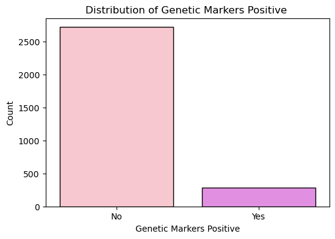

```python
plt.figure(figsize=(6, 4))
colors2=['pink','violet']
sns.countplot(data, x='Genetic_Markers_Positive', hue='Genetic_Markers_Positive', palette=colors2, edgecolor='black', legend=False)
plt.title('Distribution of Genetic Markers Positive ')
plt.xlabel('Genetic Markers Positive')
plt.ylabel('Count')
plt.show()
```

Statistical Inferences:

### 8.Bar chart of PHYSICAL ACTIVITY LEVEL

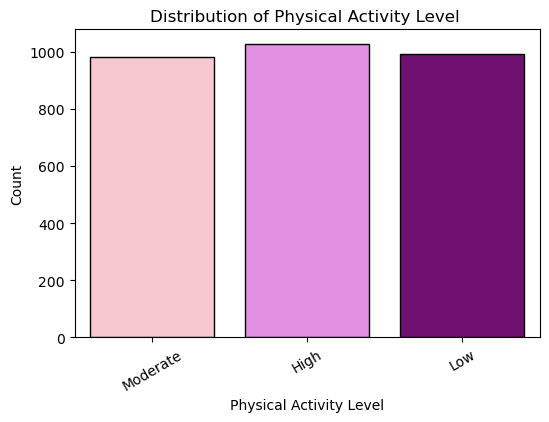

```python
plt.figure(figsize=(6, 4))
colors2=['pink','violet', 'purple']
sns.countplot(data, x='Physical_Activity_Level', hue='Physical_Activity_Level', palette=colors2, edgecolor='black', legend=False)
plt.title('Distribution of Physical Activity Level ')
plt.xlabel('Physical Activity Level')
plt.ylabel('Count')
plt.xticks(rotation=30)
plt.show()
```

Statistical Inferences:

### 9.Bar chart of ALCOHOL CONSUMPTION

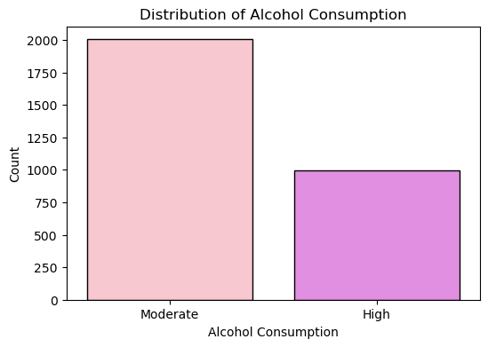

```python
plt.figure(figsize=(6, 4))
colors2=['pink','violet']
sns.countplot(data, x='Alcohol_Consumption', hue='Alcohol_Consumption', palette=colors2, edgecolor='black', legend=False)
plt.title('Distribution of Alcohol Consumption')
plt.xlabel('Alcohol Consumption')
plt.ylabel('Count')
plt.show()
```

Statistical Inferences:

### 10.Bar chart of DIET QUALITY

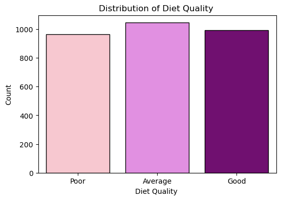

```python
plt.figure(figsize=(6, 4))
colors2=['pink','violet', 'purple']
sns.countplot(data, x='Diet_Quality', hue='Diet_Quality', palette=colors2, edgecolor='black', legend=False)
plt.title('Distribution of Diet Quality ')
plt.xlabel('Diet Quality ')
plt.ylabel('Count')
plt.show()
```

Statistical Inferences:

### 11.Bar chart of REGION

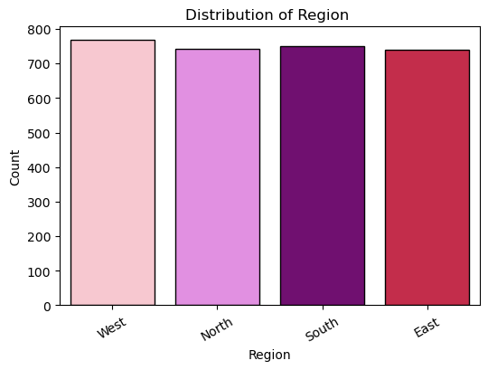

```python
plt.figure(figsize=(6, 4))
colors2=['pink','violet', 'purple','crimson']
sns.countplot(data, x='Region', hue='Region', palette=colors2, edgecolor='black', legend=False)
plt.title('Distribution of Region ')
plt.xlabel('Region')
plt.ylabel('Count')
plt.xticks(rotation=30)
plt.show()
```

### 12.Bar chart of INCOME LEVEL

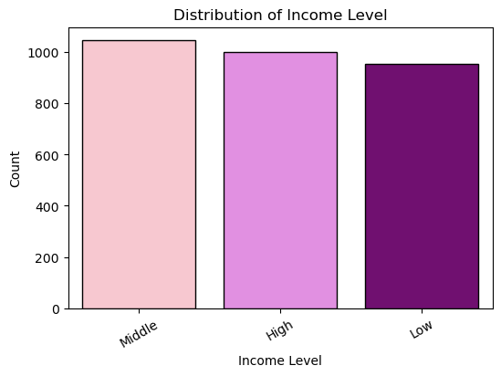

```python
plt.figure(figsize=(6, 4))
colors2=['pink','violet', 'purple']
sns.countplot(data, x='Income_Level', hue='Income_Level', palette=colors2, edgecolor='black', legend=False)
plt.title('Distribution of Income Level')
plt.xlabel('Income Level')
plt.ylabel('Count')
plt.xticks(rotation=30)
plt.show()
```

Statistical Inferences:

### 13.Bar chart of EDUCATION LEVEL

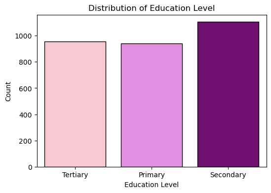

```python
plt.figure(figsize=(6, 4))
colors2=['pink','violet', 'purple']
sns.countplot(data, x='Education_Level', hue='Education_Level', palette=colors2, edgecolor='black', legend=False)
plt.title('Distribution of Education Level')
plt.xlabel('Education Level')
plt.ylabel('Count')
plt.show()
```

Interpretation: The number of students in frequency are greater for the secondary sector as compared to the primary and tertiary sector

### 14.Bar chart of ACCESS TO HEALTHCARE

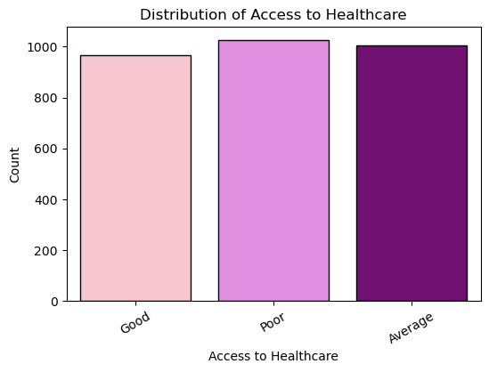

```python
plt.figure(figsize=(6, 4))
colors2=['pink','violet', 'purple']
sns.countplot(data, x='Access_to_Healthcare', hue='Access_to_Healthcare', palette=colors2, edgecolor='black', legend=False)
plt.title('Distribution of Access to Healthcare')
plt.xlabel('Access to Healthcare')
plt.ylabel('Count')
plt.xticks(rotation=30)
plt.show()
```

Interpretation: The number of individuals with and without access to healthcare is equal in the dataset on average

### 15.Bar chart of SCREENING FREQUENCY

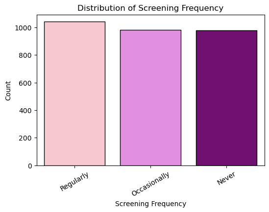

```python
plt.figure(figsize=(6, 4))
colors2=['pink','violet', 'purple']
sns.countplot(data, x='Screening_Frequency', hue='Screening_Frequency', palette=colors2, edgecolor='black', legend=False)
plt.title('Distribution of Screening Frequency')
plt.xlabel('Screening Frequency')
plt.ylabel('Count')
plt.xticks(rotation=30)
plt.show()
```

Statistical Inferences:

### 16.Bar chart of CHRONIC_LUNG_DISEASE

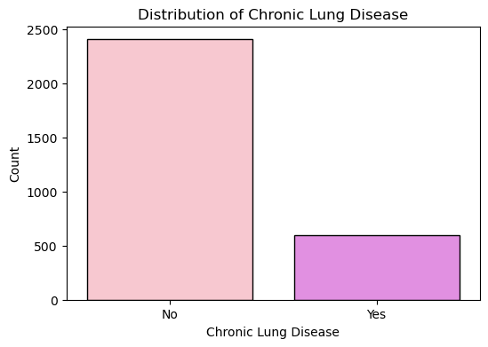

```python
plt.figure(figsize=(6, 4))
colors2=['pink','violet']
sns.countplot(data, x='Chronic_Lung_Disease', hue='Chronic_Lung_Disease', palette=colors2, edgecolor='black', legend=False)
plt.title('Distribution of Chronic Lung Disease')
plt.xlabel('Chronic Lung Disease')
plt.ylabel('Count')
plt.show()
```

The number of patients not having chonic lung disease is greater than the number of patients having it

### 17.Bar chart of LUNG_CANCER_STAGE

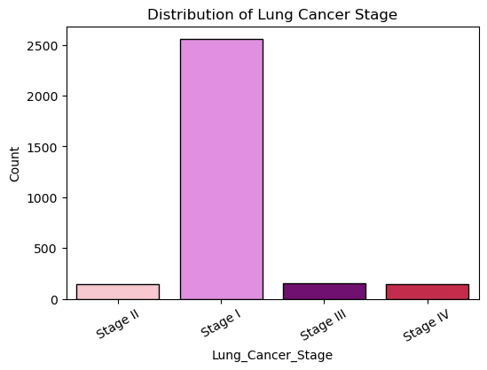

```python
plt.figure(figsize=(6, 4))
colors2=['pink','violet', 'purple','crimson']
sns.countplot(data, x='Lung_Cancer_Stage', hue='Lung_Cancer_Stage', palette=colors2, edgecolor='black', legend=False)
plt.title('Distribution of Lung Cancer Stage')
plt.xlabel('Lung_Cancer_Stage')
plt.ylabel('Count')
plt.xticks(rotation=30)
plt.show()
```

The count of patients having lung disease in stage 1 is greater than the other stages

### 18.Bar chart of SURVIVAL_STATUS

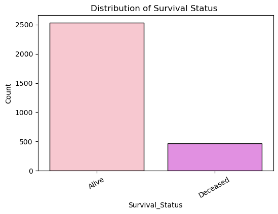

```python
plt.figure(figsize=(6, 4))
colors2=['pink','violet']
sns.countplot(data, x='Survival_Status', hue='Survival_Status', palette=colors2, edgecolor='black', legend=False)
plt.title('Distribution of Survival Status ')
plt.xlabel('Survival_Status')
plt.ylabel('Count')
plt.xticks(rotation=30)
plt.show()
```

The number of patients alive are greater than the number of people deceased due to the lung disease

# ***PIE CHARTS***

### 1.Pie Chart of OCCUPATION EXPOSURE

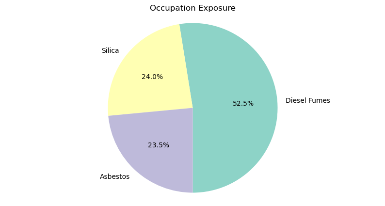

```python
plt.figure(figsize=(10,5))
data['Occupation_Exposure'].value_counts().plot.pie( autopct='%1.1f%%', startangle=270,colors=sns.color_palette('Set3'))
plt.title('Occupation Exposure')
plt.axis('equal')
plt.ylabel("")  # Hides y-axis label
plt.show()
```

The pie chart above shows that the distrubution of Diesel fumes is greater than the distribution of the other two sectors i.e silica and asbestos

### 2.Pie Chart of DIET QUALITTY

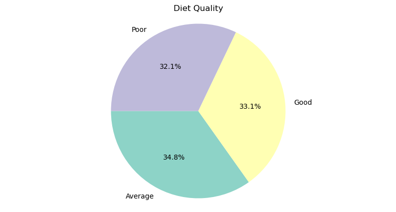

```python
plt.figure(figsize=(10,5))
data['Diet_Quality'].value_counts().plot.pie(autopct='%1.1f%%', startangle=180, colors=sns.color_palette('Set3'))
plt.title('Diet Quality')
plt.axis('equal')
plt.ylabel("")  # Hides y-axis label
plt.show()
```

As for diet quality, it shows that on average the diet quality is greater or higher than the other two sectors i.e good and poor

### 3.Pie Chart of REGION

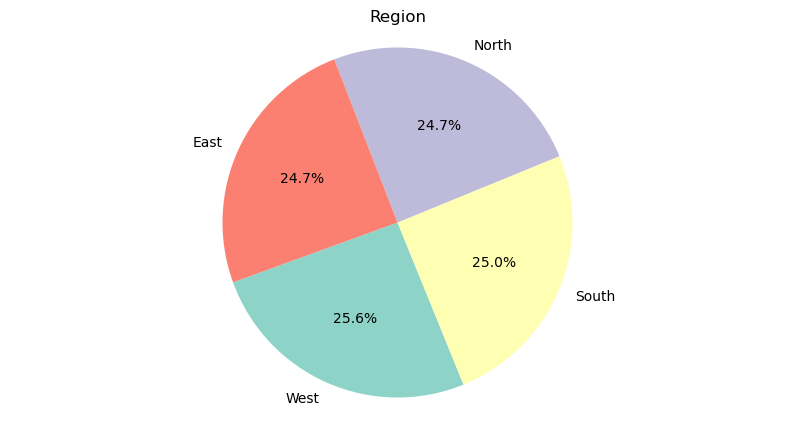

```python
plt.figure(figsize=(10,5))
data['Region'].value_counts().plot.pie(autopct='%1.1f%%', startangle=200, colors=sns.color_palette('Set3'))
plt.title('Region')
plt.axis('equal')
plt.ylabel("")  # Hides y-axis label
plt.show()
```

Region wise, the west has highest portion of distribution comapred to the other sectors

### 4.Pie Chart of EDUCATION LEVEL

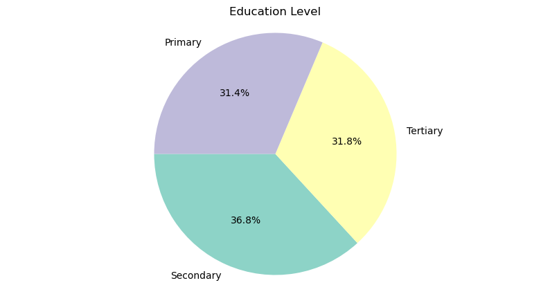

```python
plt.figure(figsize=(10,5))
data['Education_Level'].value_counts().plot.pie(autopct='%1.1f%%', startangle=180, colors=sns.color_palette('Set3'))
plt.title('Education Level')
plt.axis('equal')
plt.ylabel("")  # Hides y-axis label
plt.show()
```

As for education level, the primary sectors reports the lowest while the secondary sector reports the highest spread of education

### 5.Pie Chart of LUNG CANCER STAGE

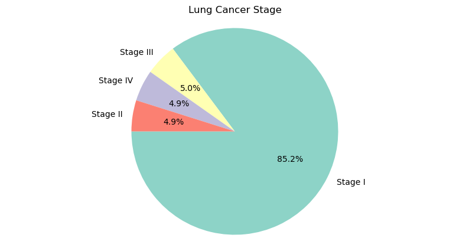

```python
plt.figure(figsize=(10,5))
data['Lung_Cancer_Stage'].value_counts().plot.pie(autopct='%1.1f%%', startangle=180, colors=sns.color_palette('Set3'))
plt.title('Lung Cancer Stage')
plt.axis('equal')
plt.ylabel("")  # Hides y-axis label
plt.show()
```

As for lung cancer stages, the stage 1 is known to be reporting the highest distribution of lung cancer as compared to other stages

# ***2.Bivariate Analysis***

# TREND ANALYSIS

### 1. Average Age Over Time

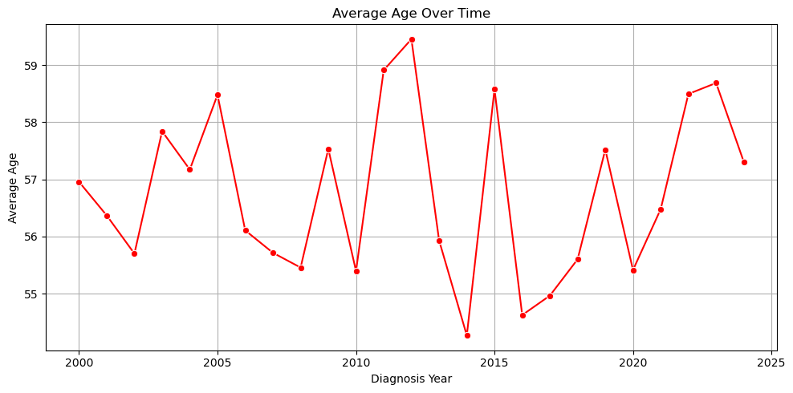

```python
plt.figure(figsize=(10,5))
trendata=data.groupby('Diagnosis_Year')['Age'].mean().reset_index() # Group and calculate average age
trendata = trendata.sort_values(by='Diagnosis_Year') # Sort by year to avoid jumbled plot
sns.lineplot(data=trendata, x='Diagnosis_Year', y='Age', marker='o', color='red')
plt.title('Average Age Over Time')
plt.xlabel('Diagnosis Year')
plt.ylabel('Average Age')
plt.grid(True)
plt.tight_layout()
plt.show()
```

Based on the linear graph above, we can predict and see that the average age at diagnosis is not stable. It is continually fluctuating with initially increasing and then decreasing so it indicates an upward and downward trending graph

### 2. Average BMI Over Time

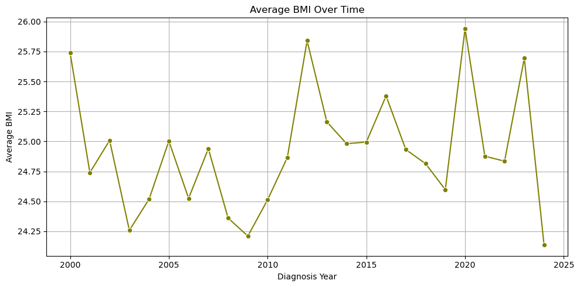

```python
plt.figure(figsize=(10,5))
trend=data.groupby('Diagnosis_Year')['BMI'].mean().reset_index()
trend=trend.sort_values(by='Diagnosis_Year')
sns.lineplot(data=trend, x='Diagnosis_Year', y='BMI', marker='o', color='olive')
plt.title('Average BMI Over Time')
plt.xlabel('Diagnosis Year')
plt.ylabel('Average BMI')
plt.tight_layout()
plt.grid(True)
plt.show()
```

Based on this graph above, we can see that the average BMI was following a downward trend initially but then slowly increased and then dramatically increased from 2008 to 2012 and then follows downward cycles constantly

### 3.Average Cigarettes per day over year

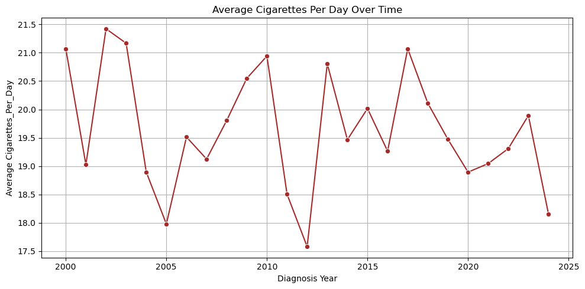

```python
plt.figure(figsize=(10,5))
trend1=data.groupby('Diagnosis_Year')['Cigarettes_Per_Day'].mean().reset_index()
trend1=trend1.sort_values(by='Diagnosis_Year')
sns.lineplot(data=trend1, x='Diagnosis_Year', y='Cigarettes_Per_Day', marker='o', color='brown')
plt.title('Average Cigarettes Per Day Over Time')
plt.xlabel('Diagnosis Year')
plt.ylabel('Average Cigarettes_Per_Day')
plt.tight_layout()
plt.grid(True)
plt.show()
```

The average cigarettes per day overall follows a downward pattern with a little bit of increase in between

### 4. Total diagnosis over year

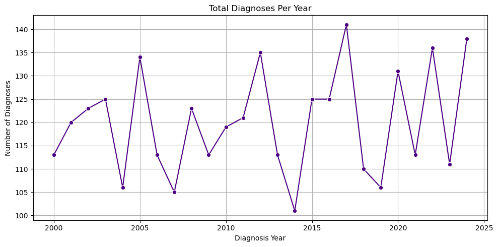

```python
diagnoses_trend =data.groupby('Diagnosis_Year')['Patient_ID'].count().reset_index()
diagnoses_trend.rename(columns={'Patient_ID': 'Total_Diagnoses'}, inplace=True)
plt.figure(figsize=(10, 5))
sns.lineplot(data=diagnoses_trend, x='Diagnosis_Year', y='Total_Diagnoses', marker='o',color='indigo')
plt.title('Total Diagnoses Per Year')
plt.xlabel('Diagnosis Year')
plt.ylabel('Number of Diagnoses')
plt.grid(True)
plt.tight_layout()
plt.show()
```

The total number of diagnosis follows an initial upward trend slighlty with rapid equal amounts of upward and downward trends later on

### 5.Combined trend plot of any two

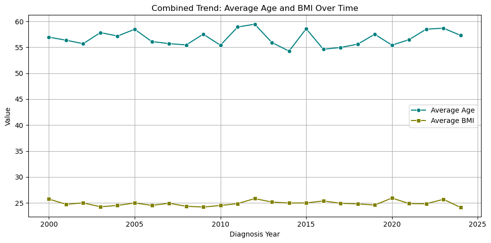

```python
combined_trend= data.groupby('Diagnosis_Year')[['Age', 'BMI']].mean().reset_index()
plt.figure(figsize=(10, 5))
sns.lineplot(data=combined_trend, x='Diagnosis_Year', y='Age', label='Average Age', marker='o',color='teal')
sns.lineplot(data=combined_trend, x='Diagnosis_Year', y='BMI', label='Average BMI', marker='s',color='olive')
plt.title('Combined Trend: Average Age and BMI Over Time')
plt.xlabel('Diagnosis Year')
plt.ylabel('Value')
plt.legend()
plt.grid(True)
plt.tight_layout()
plt.show()
```

The combined trend of the Average age and Average BMI show higher upward and downward cyclical fluctuations for the average Age plot as compared to the average BMI plot whihc is more constant

# SCATTER PLOTS

### 1. Age vs Years Smoking

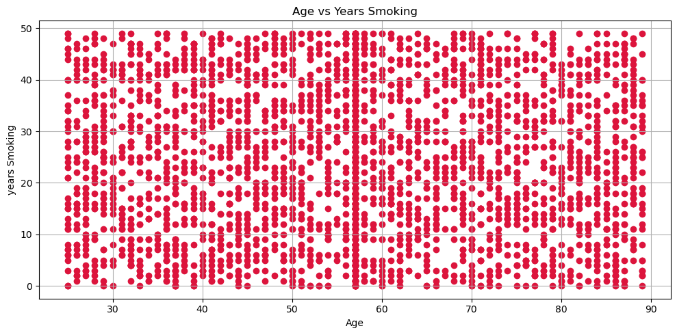

```python
plt.figure(figsize=(10,5))
plt.scatter(data['Age'],data['Years_Smoking'],color='crimson')
plt.title("Age vs Years Smoking")
plt.xlabel("Age")
plt.ylabel("years Smoking")
plt.grid(True)
plt.tight_layout()
plt.show()
```

Statistical Inferences:

Correlation: The scatter plot does not show a clear pattern or trend, suggesting a random relationship between age and years of smoking. This indicates that there is no strong correlation between the two variables.

Distribution: The data points are widely scattered across the plot, indicating variability in the number of years smoking across different ages.

Clusters: There are no distinct clusters or groupings of data points, further supporting the lack of a clear relationship between age and years of smoking.

Interpretation: The scatter plot suggests that age does not significantly influence the number of years an individual has been smoking. The relationship between these two variables appears to be random

### 2. Age vs Cigarettes_Per_Day

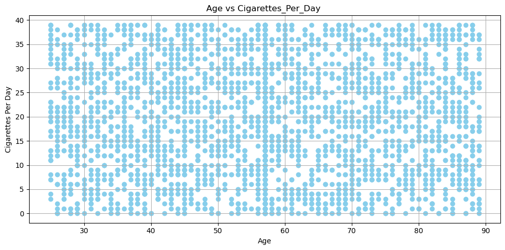

```python
plt.figure(figsize=(10,5))
plt.scatter(data['Age'],data['Cigarettes_Per_Day'],color='skyblue')
plt.title("Age vs Cigarettes_Per_Day ")
plt.xlabel("Age")
plt.ylabel("Cigarettes Per Day")
plt.grid(True)
plt.tight_layout()
plt.show()
```

Same statistical summary as done for age vs smoking

### 3. Age vs BMI

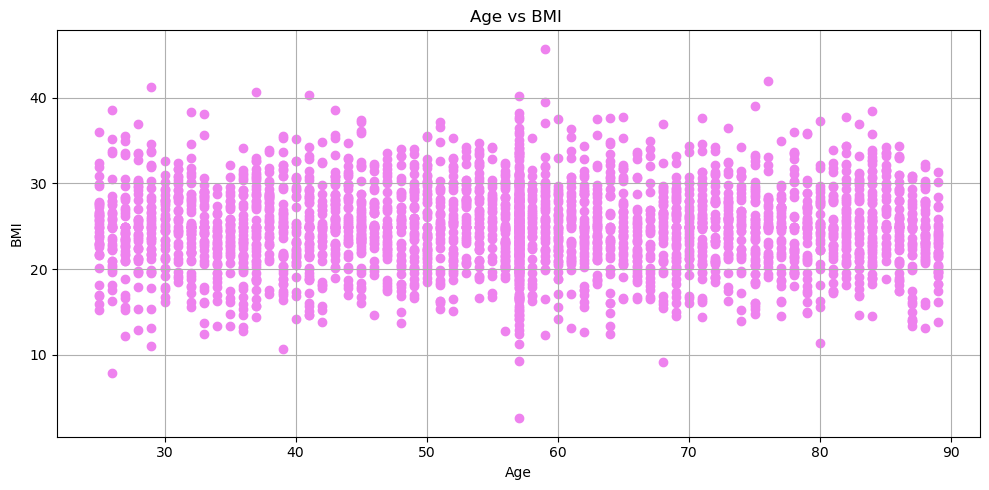

```python
plt.figure(figsize=(10,5))
plt.scatter(data['Age'],data['BMI'],color='violet')
plt.title("Age vs BMI ")
plt.xlabel("Age")
plt.ylabel("BMI")
plt.grid(True)
plt.tight_layout()
plt.show()
```

Statistical Inferences:

Correlation: The scatter plot does not show a clear linear relationship between age and BMI. The points are widely scattered across all age groups, indicating that age does not strongly influence BMI.

Distribution: The BMI values appear to be relatively consistent across different ages, with most values falling between a BMI of 15 and 35.

Interpretation: The scatter plot suggests that BMI is not significantly influenced by age. The relationship between these two variables appears to be random, with BMI values distributed fairly evenly across different ages.

### 4. Age vs Diagnosis_Year

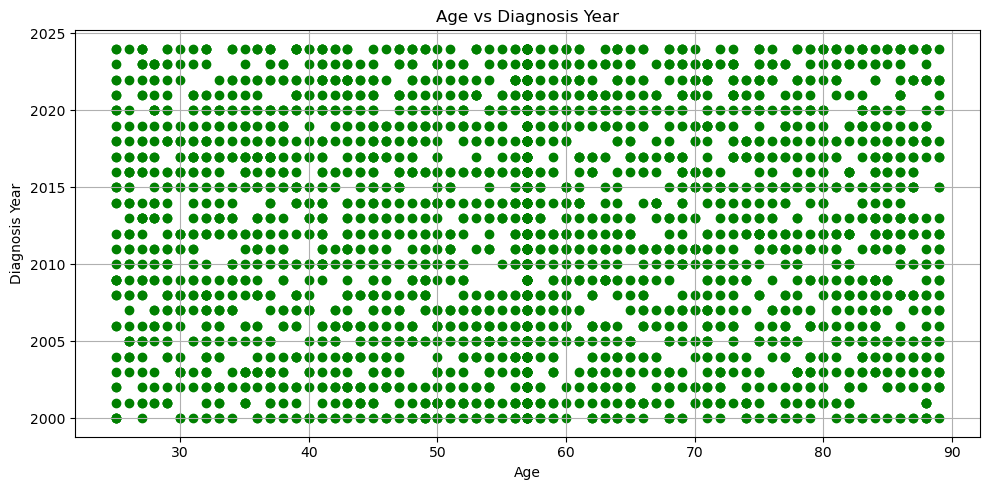

```python
plt.figure(figsize=(10,5))
plt.scatter(data['Age'],data['Diagnosis_Year'],color='green')
plt.title("Age vs Diagnosis Year")
plt.xlabel("Age")
plt.ylabel("Diagnosis Year")
plt.grid(True)
plt.tight_layout()
plt.show()
```

Based on the graph above, it does not show anykind of correlation between age and diagnosis years as points are closely and evenly scattered

# CORRELATION HEATMAP

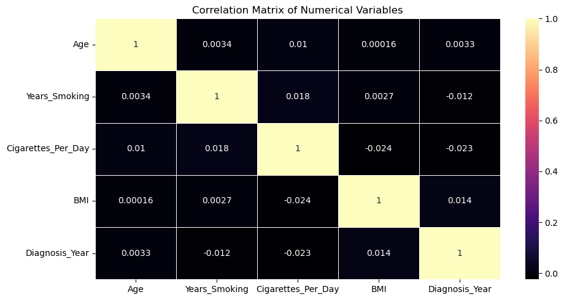

```python
plt.figure(figsize=(10, 5))
corr_matrix= data.corr(numeric_only=True)
sns.heatmap(corr_matrix, annot=True, cmap='magma', linewidths=0.5)
plt.title("Correlation Matrix of Numerical Variables")
plt.tight_layout()
plt.show()
```

Statistical Inferences:

Perfect Positive Correlation: Each variable has a perfect positive correlation (value of 1) with itself, as expected.

Weak Correlations: The correlations between different pairs of variables are very weak, with values close to zero. This indicates that there are no strong linear relationships between these variables. No Strong Positive or Negative Correlations: There are no strong positive or negative correlations between any pair of different variables in the dataset.

Interpretation: The heatmap suggests that the numerical variables in the dataset do not have significant linear relationships with each other. This means that changes in one variable do not strongly predict changes in another variable.

# BOXPLOTS GROUPED BY CLASS LABELS

### 1.Age grouped by Lung Cancer status

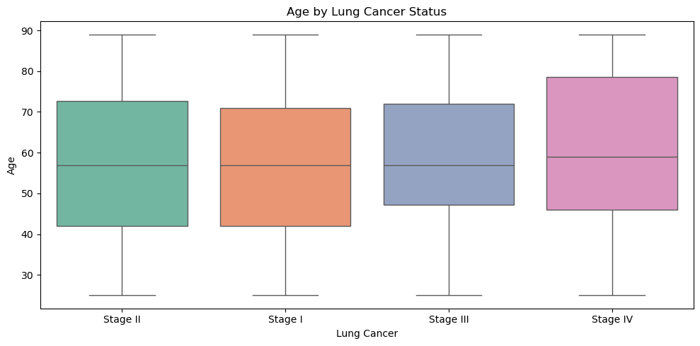

```python
plt.figure(figsize=(10, 5))
sns.boxplot(x='Lung_Cancer_Stage', y='Age', data=data, hue='Lung_Cancer_Stage', palette='Set2')
plt.title('Age by Lung Cancer Status')
plt.xlabel('Lung Cancer')
plt.ylabel('Age')
plt.tight_layout()
plt.show()
```

Statistical inferences:

Median Age: The median age (the line inside each box) is relatively similar across all stages, indicating that the central tendency of age does not vary much with the stage of lung cancer.

Interquartile Range (IQR): The IQR (the length of each box) represents the middle 50% of ages. The IQRs are quite similar across all stages, suggesting that the spread of ages within the middle 50% is consistent.

Range: The whiskers extend to show the range of ages within 1.5 times the IQR from either end of the box. All stages have similar ranges, indicating that the overall spread of ages is comparable.

Outliers: There do not appear to be any outliers in any of the stages, which means that there are no ages that are significantly different from the rest.

Overall, the age distribution among different lung cancer stages appears to be quite similar based on this box plot analysis.

### 2. BMI grouped by Lung Cancer status

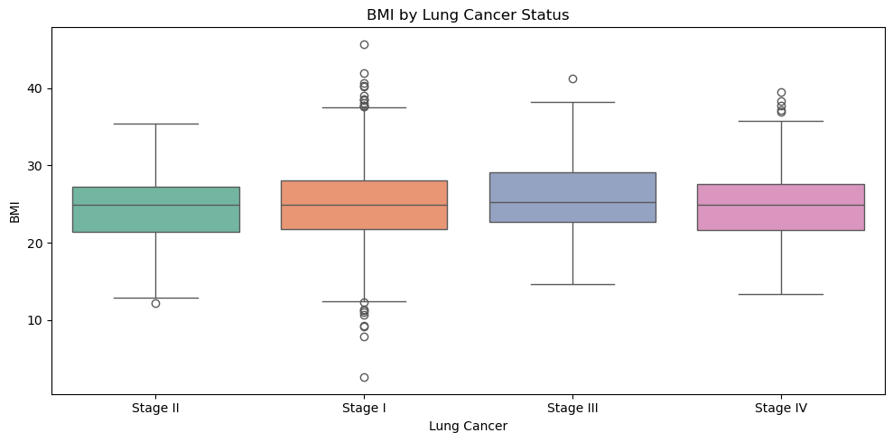

```python
plt.figure(figsize=(10, 5))
sns.boxplot(x='Lung_Cancer_Stage', y='BMI', data=data, hue='Lung_Cancer_Stage', palette='Set2')
plt.title('BMI by Lung Cancer Status')
plt.xlabel('Lung Cancer')
plt.ylabel('BMI')
plt.tight_layout()
plt.show()
```

Statistical inferences:

Median BMI: The median BMI (the line inside each box) is relatively similar across all stages, indicating that the central tendency of BMI does not vary much with the stage of lung cancer.

Interquartile Range (IQR): The IQR (the length of each box) represents the middle 50% of BMI values. The IQRs are quite similar across all stages, suggesting that the spread of BMI within the middle 50% is consistent.

Range: The whiskers extend to show the range of BMI values within 1.5 times the IQR from either end of the box. All stages have similar ranges, indicating that the overall spread of BMI is comparable.

Overall, the BMI distribution among different lung cancer stages appears to be quite similar based on this box plot analysis.

### 2. Cigarettes_Per_Day grouped by Lung Cancer status

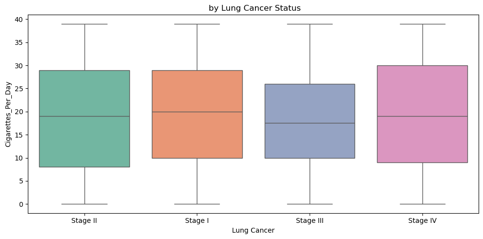

```python
plt.figure(figsize=(10, 5))
sns.boxplot(x='Lung_Cancer_Stage', y='Cigarettes_Per_Day', data=data, hue='Lung_Cancer_Stage', palette='Set2')
plt.title(' by Lung Cancer Status')
plt.xlabel('Lung Cancer')
plt.ylabel('Cigarettes_Per_Day')
plt.tight_layout()
plt.show()
```

Statistical inferences:

Median Cigarettes Per Day: The median number of cigarettes smoked per day is relatively similar across all stages, with Stage I having a slightly higher median compared to the other stages.

Interquartile Range (IQR): The IQR (the length of each box) represents the middle 50% of cigarettes smoked per day. The IQRs are quite similar across all stages, suggesting that the spread of cigarettes smoked within the middle 50% is consistent.

Range: The whiskers extend to show the range of cigarettes smoked per day within 1.5 times the IQR from either end of the box. All stages have similar ranges, indicating that the overall spread of cigarettes smoked per day is comparable.

Overall, the distribution of cigarettes smoked per day among different lung cancer stages appears to be quite similar based on this box plot analysis.

# *** REPORT INSIGHTS***

# Lung Cancer Trends Analysis Summary

## Gender and Lifestyle Patterns

- **Gender Distribution**: The dataset shows a nearly equal gender split, with a slight **female majority**.
- **Smoking Habits by Gender**: Both genders smoke similar amounts on average, but **males show greater variation**.
- **Alcohol Consumption by Gender**: No major gender difference in alcohol intake, though **males again show a wider range**.

## Family and Genetic History

- **Family History of Lung Cancer**: About **49%** of patients reported a family history, indicating a **strong genetic predisposition**.

## Prevention and Intervention Insights

- **Early Detection**: Lower cancer stages at detection are associated with better outcomes.
- **Lifestyle Changes**: Reducing smoking, alcohol, and pollutant exposure can significantly lower risks.
- **Targeted Interventions**: Especially needed for those with family history or high-risk environmental/occupational exposure.
- **Public Health Campaigns**: Can raise awareness about preventable risk factors and promote lifestyle changes.

## Overall Conclusion

Lung cancer development is **multi-factorial**, influenced by:

- **Lifestyle factors**: especially smoking
- **Genetic predisposition**: family history
- **Environmental exposure**: pollution and occupational hazards

A **holistic prevention approach** is essential, combining **early detection**, **lifestyle interventions**, and **targeted public health strategies** to reduce lung cancer incidence and severity.